# TP1

Cristian Salinas

2023-10-07

```r
library("readxl")
library('tidyverse')
library('here')
```

```r
library(readxl)#lectura
library(dplyr) #manipulacion de datos
library(kableExtra) #tablas
library(ggplot2) #graficos
library(tidyverse) #manipulacion de datos
library(ggpubr) #para juntar
library(ggforce) # grafico de violin y jitter
library(GGally) # ggpairs
library(corrplot) # para correlogramas
```

```r
here::here()
```

```
## [1] "C:/01_ds/tp1-AID/tp1-AID"
```

## Ejercicio 1 (Transformaciones de datos).

Seis candidatas son evaluadas para el puesto de recepcionista en una em- presa, para ello pasan por dos entrevistas. En la primera las evalúa el responsa- ble de recursos humanos de la empresa (juez 1) y en la segunda el responsable del área de la cual van a depender (juez 2). La asignación de puntajes es en cordialidad, presencia y manejo de idiomas. Los puntajes asignados indepen- dientemente por estos jueces se encuentran en el archivo recepcionistas.xls.

### Lectura y Transformación de Datos

1. Calcule en promedio por juez de cada una de las aspirantes. ¿Cuál le parece que seleccionaría cada uno de ellos? ¿Existe coincidencia?

```r
recepcionistas <- read_excel("recepcionistas.xls")
```

```r
glimpse(recepcionistas)
```

```
## Rows: 6
## Columns: 7
## $ candidatos    <chr> "Mariana", "Maia", "Sabrina", "Daniela", "Alejandra", "C…
## $ `cord.juez 1` <dbl> 80, 80, 90, 80, 70, 90
## $ pres.juez1    <dbl> 90, 90, 60, 50, 60, 85
## $ idiom.juez1   <dbl> 70, 60, 50, 50, 50, 60
## $ `cord.juez 2` <dbl> 60, 65, 70, 70, 55, 80
## $ pres.juez2    <dbl> 78, 90, 60, 58, 70, 90
## $ idiom.juez2   <dbl> 80, 65, 50, 40, 65, 40
```

Se puede observar la existencia de espacios en los nombres de las columnas. A continuación se cambia el nombre de las columnas para un mejor desarrollo.

```r
colnames(recepcionistas) <- gsub(" ", "", colnames(recepcionistas))
```

```r
colnames(recepcionistas)
```

```
## [1] "candidatos"  "cord.juez1"  "pres.juez1"  "idiom.juez1" "cord.juez2"
## [6] "pres.juez2"  "idiom.juez2"
```

```r
recepcionistas %>% head()
```

```
## # A tibble: 6 × 7
##   candidatos cord.juez1 pres.juez1 idiom.juez1 cord.juez2 pres.juez2 idiom.juez2
##   <chr>           <dbl>      <dbl>       <dbl>      <dbl>      <dbl>       <dbl>
## 1 Mariana            80         90          70         60         78          80
## 2 Maia               80         90          60         65         90          65
## 3 Sabrina            90         60          50         70         60          50
## 4 Daniela            80         50          50         70         58          40
## 5 Alejandra          70         60          50         55         70          65
## 6 Carla              90         85          60         80         90          40
```

En el dataset original se puede observar que no esta en un formato adecuado para un analisis de datos usando la filosofia Tidy. Por ello, se transforman los datos para responder las preguntas del trabajo practico de una manera mas practica.

```r
recep_tidy = recepcionistas %>%  pivot_longer(cols = 2:7, # Columnas que deseas transformar
               names_to = "Variable",   # Nombre de la nueva columna de variables
               values_to = "Puntuacion") %>% # Nombre de la nueva columna que tendra los valores
  separate_wider_delim(Variable, delim = ".", names = c("rubro", "juez")) %>% # Se separan la columna Variable en 2 variables
  mutate(candidatos = as.factor(candidatos), # las variables categorias se pasan a tipo factor.
         rubro = as.factor(rubro),
         juez = as.factor(juez))
```

```r
recep_tidy %>% head(5)
```

```
## # A tibble: 5 × 4
##   candidatos rubro juez  Puntuacion
##   <fct>      <fct> <fct>      <dbl>
## 1 Mariana    cord  juez1         80
## 2 Mariana    pres  juez1         90
## 3 Mariana    idiom juez1         70
## 4 Mariana    cord  juez2         60
## 5 Mariana    pres  juez2         78
```

### a. Calcule en promedio por juez de cada una de las aspirantes. ¿Cuál le parece que seleccionaría cada uno de ellos? ¿Existe coincidencia?

```r
recep_tidy %>%
  group_by(juez, candidatos) %>%
  summarise(promedio = mean(Puntuacion)) %>%
  pivot_wider(names_from = juez, values_from = promedio)
```

```
## # A tibble: 6 × 3
##   candidatos juez1 juez2
##   <fct>      <dbl> <dbl>
## 1 Alejandra   60    63.3
## 2 Carla       78.3  70
## 3 Daniela     60    56
## 4 Maia        76.7  73.3
## 5 Mariana     80    72.7
## 6 Sabrina     66.7  60
```

```r
recep_tidy %>%
  group_by(juez, candidatos) %>%
  summarise(promedio = mean(Puntuacion)) %>%
  filter(juez =="juez1") %>%
  arrange(-promedio) %>% head(1)
```

```
## # A tibble: 1 × 3
## # Groups:   juez [1]
##   juez  candidatos promedio
##   <fct> <fct>         <dbl>
## 1 juez1 Mariana          80
```

```r
recep_tidy %>%
  group_by(juez, candidatos) %>%
  summarise(promedio = mean(Puntuacion)) %>%
  filter(juez =="juez2") %>%
  arrange(-promedio)%>% head(1)
```

```
## # A tibble: 1 × 3
## # Groups:   juez [1]
##   juez  candidatos promedio
##   <fct> <fct>         <dbl>
## 1 juez2 Maia           73.3
```

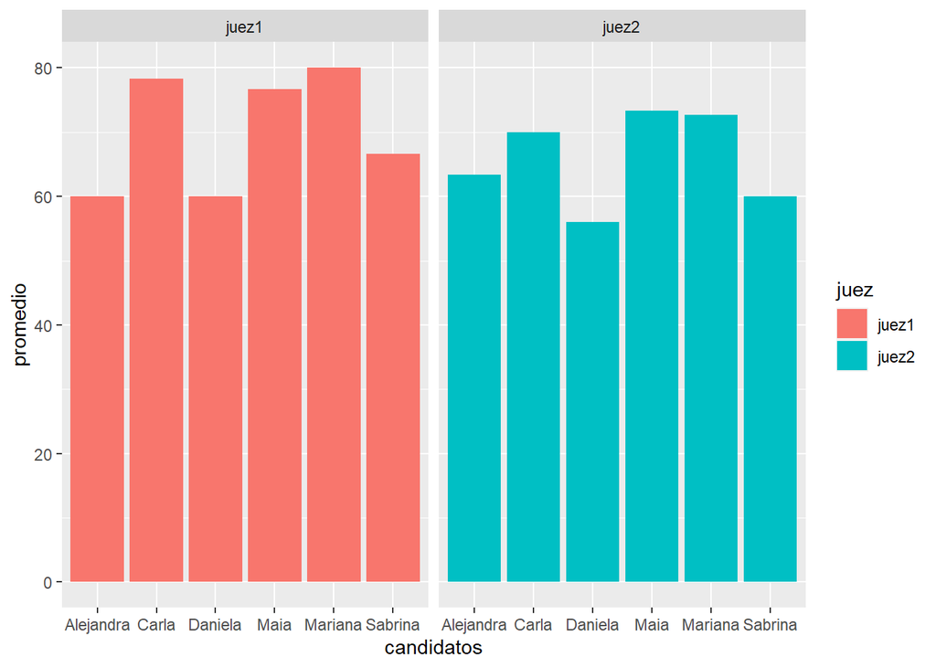

```r
recep_tidy %>%
  group_by(juez, candidatos) %>%
  summarise(promedio = mean(Puntuacion)) %>%
  ggplot(aes(x=candidatos, y = promedio))+
  geom_col(aes(fill=juez))+
  facet_wrap(~juez, ncol=2)
```

**Respuesta: las candidatas elegidas fueron Mariana (Juez1) y Maia(Juez2)**

### b. Calcule el promedio de cada una de las aspirantes tomando en cuenta todos los rubros y ambos jueces.

```r
recep_tidy %>%
  group_by(candidatos) %>%
  summarise(promedio = mean(Puntuacion)) %>%
  arrange(-promedio)
```

```
## # A tibble: 6 × 2
##   candidatos promedio
##   <fct>         <dbl>
## 1 Mariana        76.3
## 2 Maia           75
## 3 Carla          74.2
## 4 Sabrina        63.3
## 5 Alejandra      61.7
## 6 Daniela        58
```

### c. Transformar las puntuaciones observadas de modo tal que cada una de las seis variables tenga media 0 y dispersión 1. ¿Cuál sería el objetivo de esta transformación?

```r
recep_tidy %>%
  pivot_wider(names_from = c(rubro, juez), values_from = Puntuacion) %>%
  mutate(cord_juez1 = scale(cord_juez1),
         pres_juez1 = scale(pres_juez1),
         idiom_juez1 = scale(idiom_juez1),
         cord_juez2 = scale(cord_juez2),
         pres_juez2 = scale(pres_juez2),
         idiom_juez2 = scale(idiom_juez2))
```

```
## # A tibble: 6 × 7
##   candidatos cord_juez1[,1] pres_juez1[,1] idiom_juez1[,1] cord_juez2[,1]
##   <fct>               <dbl>          <dbl>           <dbl>          <dbl>
## 1 Mariana            -0.221          0.982           1.63          -0.761
## 2 Maia               -0.221          0.982           0.408         -0.190
## 3 Sabrina             1.11          -0.702          -0.816          0.381
## 4 Daniela            -0.221         -1.26           -0.816          0.381
## 5 Alejandra          -1.55          -0.702          -0.816         -1.33
## 6 Carla               1.11           0.702           0.408          1.52
## # ℹ 2 more variables: pres_juez2 <dbl[,1]>, idiom_juez2 <dbl[,1]>
```

*Respuesta: El objetivo de esta transformación es hacer comparables los valores de ambos jueces en todos los rubros.*

### d. Transformar las puntuaciones de modo tal que cada candidata tenga para cada juez media 0 y dispersión 1. ¿Cuál sería el objetivo de esta transfor- mación?

```r
recep_tidy %>%
  group_by(juez, candidatos) %>%
  summarise(promedio = mean(Puntuacion)) %>%
  pivot_wider(names_from = juez, values_from = promedio) %>%
  mutate(juez1 = scale(juez1),
         juez2 = scale(juez2))
```

```
## # A tibble: 6 × 3
##   candidatos juez1[,1] juez2[,1]
##   <fct>          <dbl>     <dbl>
## 1 Alejandra     -1.12     -0.356
## 2 Carla          0.874     0.573
## 3 Daniela       -1.12     -1.38
## 4 Maia           0.693     1.04
## 5 Mariana        1.06      0.945
## 6 Sabrina       -0.392    -0.821
```

### e. Grafique los perfiles multivariados de cada una de las candidatas para ambas transformaciones. ¿Qué observa?

#### Sin transformar.

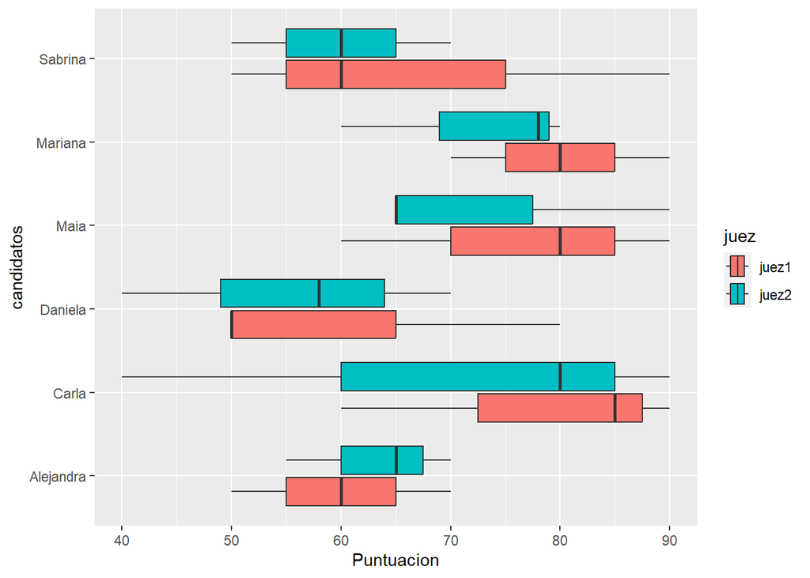

```r
recep_tidy %>% ggplot(aes(x=Puntuacion, y = candidatos, fill = juez)) +
  geom_boxplot()
```

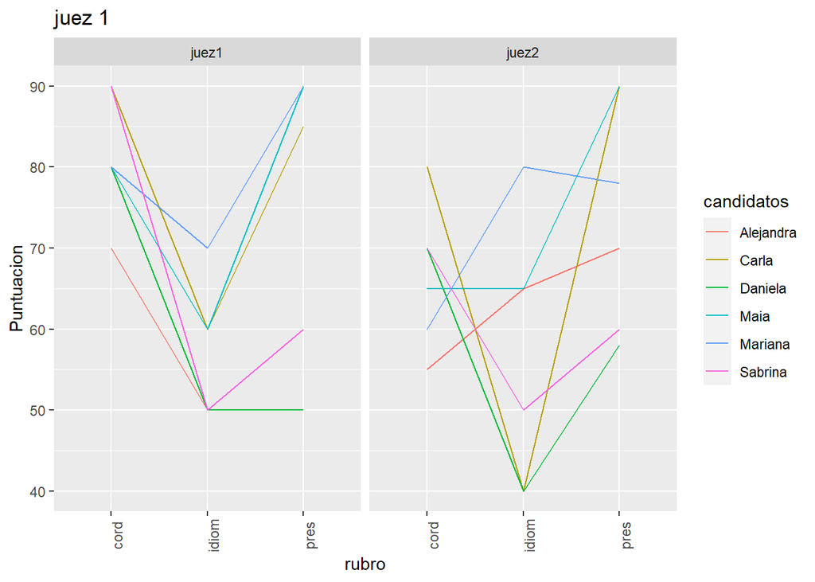

```r
ggplot(recep_tidy,aes(x=rubro,y=Puntuacion,color=candidatos))+
  geom_line(aes(group =candidatos))+
  labs(title = "juez 1") +
  theme(axis.text.x  = element_text(angle=90))+
  facet_row(~juez)
```

#### Con Variables Transformadas

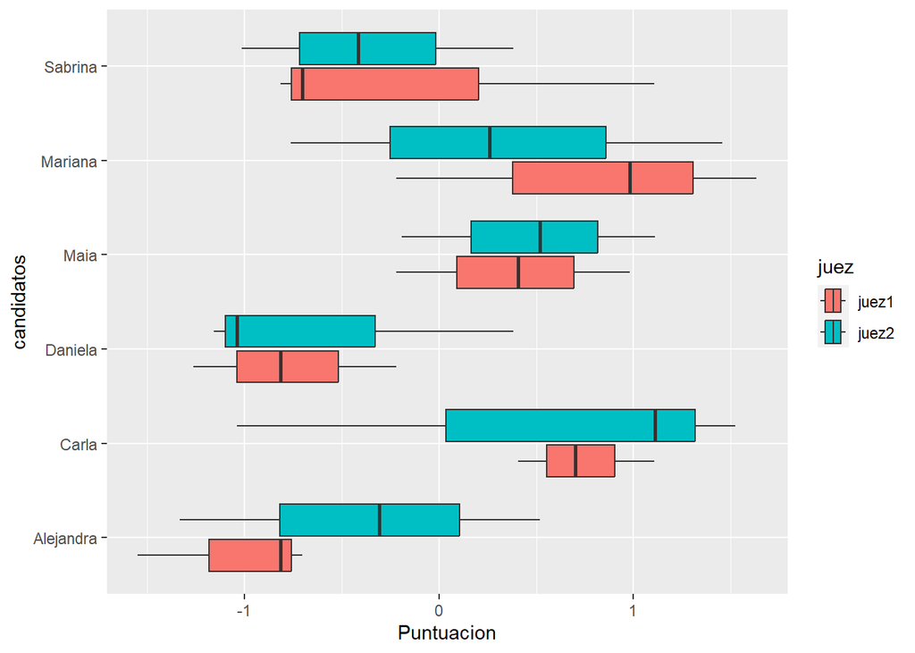

```r
recep_tidy %>%
  pivot_wider(names_from = c(rubro, juez), values_from = Puntuacion) %>%
  mutate(cord_juez1 = scale(cord_juez1),
         pres_juez1 = scale(pres_juez1),
         idiom_juez1 = scale(idiom_juez1),
         cord_juez2 = scale(cord_juez2),
         pres_juez2 = scale(pres_juez2),
         idiom_juez2 = scale(idiom_juez2)) %>%
        pivot_longer(cols = 2:7, # Columnas que deseas transformar
               names_to = "Variable",   # Nombre de la nueva columna de variables
               values_to = "Puntuacion") %>% # Nombre de la nueva columna que tendra los valores
  separate_wider_delim(Variable, delim = "_", names = c("rubro", "juez")) %>% # Se separan la columna Variable en 2 variables
  mutate(candidatos = as.factor(candidatos), # las variables categorias se pasan a tipo factor.
         rubro = as.factor(rubro),
         juez = as.factor(juez))%>%
  ggplot(aes(x=Puntuacion, y = candidatos, fill = juez)) +
  geom_boxplot()
```

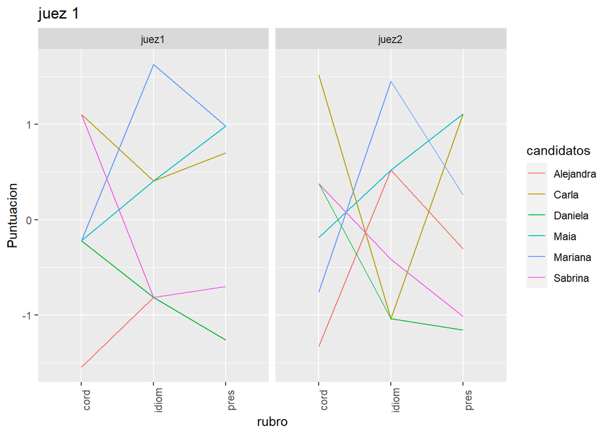

```r
recep_tidy %>%
  pivot_wider(names_from = c(rubro, juez), values_from = Puntuacion) %>%
  mutate(cord_juez1 = scale(cord_juez1),
         pres_juez1 = scale(pres_juez1),
         idiom_juez1 = scale(idiom_juez1),
         cord_juez2 = scale(cord_juez2),
         pres_juez2 = scale(pres_juez2),
         idiom_juez2 = scale(idiom_juez2)) %>%
        pivot_longer(cols = 2:7, # Columnas que deseas transformar
               names_to = "Variable",   # Nombre de la nueva columna de variables
               values_to = "Puntuacion") %>% # Nombre de la nueva columna que tendra los valores
  separate_wider_delim(Variable, delim = "_", names = c("rubro", "juez")) %>% # Se separan la columna Variable en 2 variables
  mutate(candidatos = as.factor(candidatos), # las variables categorias se pasan a tipo factor.
         rubro = as.factor(rubro),
         juez = as.factor(juez)) %>%
  ggplot(aes(x=rubro,y=Puntuacion,color=candidatos))+
  geom_line(aes(group =candidatos))+
  labs(title = "juez 1") +
  theme(axis.text.x  = element_text(angle=90))+
  facet_row(~juez)
```

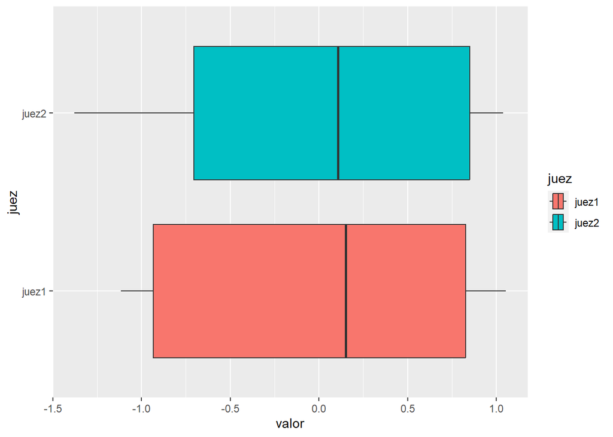

```r
recep_tidy %>%
  group_by(juez, candidatos) %>%
  summarise(promedio = mean(Puntuacion)) %>%
  pivot_wider(names_from = juez, values_from = promedio) %>%
  mutate(juez1 = scale(juez1),
         juez2 = scale(juez2)) %>%
  pivot_longer(cols=2:3, names_to = 'juez', values_to = 'valor') %>%
  ggplot(aes(y= juez, x = valor, fill= juez))+
  geom_boxplot()
```

*Respuesta: La primera transformacion (6 columnnas) es útil para comparar las puntuaciones individuales de cada candidata y rubro. Mientras que la segunda transformación es util para comprar en promedio la puntuación de los jueces*

## Ejercicio 2

(Tipos de variables resúmenes: (Datos: Internet. 2013)). Se han registrado sobre 1500 individuos las variables siguientes: ID: número de identificación del registro. Nacionalidad Edad: cumplida en años Sexo: Masculino (1) Femenino (2) Estatura: en m Sitio: sitio preferido al que se conecta; 1- chat 2 - correo electrónico 3- buscadores 4 – software 5 – música 6 – deportes 7 - otros Uso: Tiempo de uso promedio por día en minutos Temperatura: media anual de la zona de residencia Autos: cantidad de autos en la manzana donde reside Cigarrillos: Cantidad de cigarrillos consumidos mientras utiliza Internet

```r
internet = read_excel("Internet2013.xls")
```

Gráfico de cajas de explorar las variables. Tener en cuenta que están escaladas.

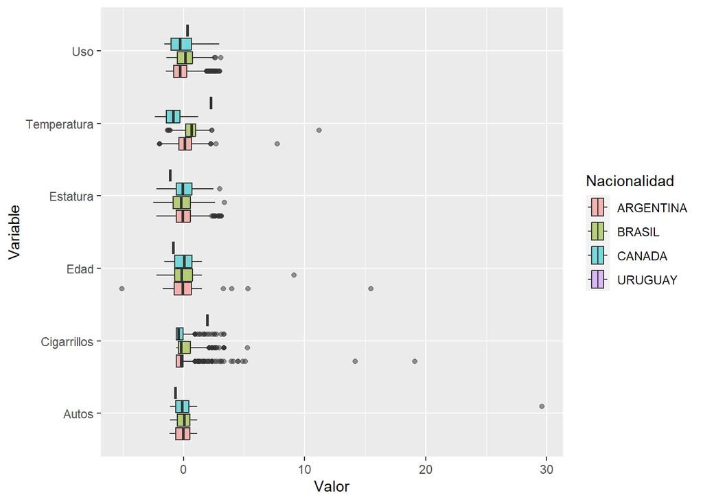

```r
internet %>% select(Nacionalidad,
                    Edad,
                    Estatura,
                    Uso,
                    Temperatura,
                    Autos,
                    Cigarrillos) %>%
  mutate_if(is.numeric, ~scale(.)) %>%
  pivot_longer(names_to ="Variable", values_to = 'Valor', cols = 2:7) %>%
  ggplot(aes(x=Valor, y= Variable, fill = Nacionalidad))+
  geom_boxplot(alpha=0.5)
```

### a. Clasificar las variables de la base. Para las variables numéricas construir un gráfico de coordenadas paralelas.

*Respuesta: Tipo de datos en variables de la base de datos.*

```r
str(internet)
```

```
## tibble [1,500 × 10] (S3: tbl_df/tbl/data.frame)
##  $ ID          : num [1:1500] 1 2 3 4 5 6 7 8 9 10 ...
##  $ Nacionalidad: chr [1:1500] "ARGENTINA" "ARGENTINA" "ARGENTINA" "ARGENTINA" ...
##  $ Edad        : num [1:1500] 17 19 28 47 27 17 54 11 27 40 ...
##  $ Sexo        : num [1:1500] 2 1 1 1 2 1 1 2 2 1 ...
##  $ Estatura    : num [1:1500] 1.55 1.89 1.57 1.55 1.61 1.81 1.66 1.69 1.57 1.56 ...
##  $ Sitio       : num [1:1500] 2 3 2 6 7 1 7 2 5 4 ...
##  $ Uso         : num [1:1500] 105 106 106 229 33 89 185 220 210 196 ...
##  $ Temperatura : num [1:1500] 9 18 6 10 -3 16 18 15 19 15 ...
##  $ Autos       : num [1:1500] 111 121 169 89 114 89 115 65 107 12 ...
##  $ Cigarrillos : num [1:1500] 6 6 4 9 0 4 1 23 0 3 ...
```

```r
internet$Nacionalidad = as.factor(internet$Nacionalidad)
```

```r
sitios = data.frame(id=c(1,2,3,4,5,6,7), Sitio= c("chat", "email", "buscadores", "software", "musica", "deportes", "otros"))
sitios
```

```
##   id      Sitio
## 1  1       chat
## 2  2      email
## 3  3 buscadores
## 4  4   software
## 5  5     musica
## 6  6   deportes
## 7  7      otros
```

Se realizó un left_join() para agregar los valores respectivos a cada Sitio.

```r
internet %>% left_join(sitios, by=c("Sitio"= "id"))
```

```
## # A tibble: 1,500 × 11
##       ID Nacionalidad  Edad  Sexo Estatura Sitio   Uso Temperatura Autos
##    <dbl> <fct>        <dbl> <dbl>    <dbl> <dbl> <dbl>       <dbl> <dbl>
##  1     1 ARGENTINA       17     2     1.55     2   105           9   111
##  2     2 ARGENTINA       19     1     1.89     3   106          18   121
##  3     3 ARGENTINA       28     1     1.57     2   106           6   169
##  4     4 ARGENTINA       47     1     1.55     6   229          10    89
##  5     5 CANADA          27     2     1.61     7    33          -3   114
##  6     6 ARGENTINA       17     1     1.81     1    89          16    89
##  7     7 ARGENTINA       54     1     1.66     7   185          18   115
##  8     8 ARGENTINA       11     2     1.69     2   220          15    65
##  9     9 ARGENTINA       27     2     1.57     5   210          19   107
## 10    10 ARGENTINA       40     1     1.56     4   196          15    12
## # ℹ 1,490 more rows
## # ℹ 2 more variables: Cigarrillos <dbl>, Sitio.y <chr>
```

*Respuesta: Grafico de coordenadas Paralelas.*

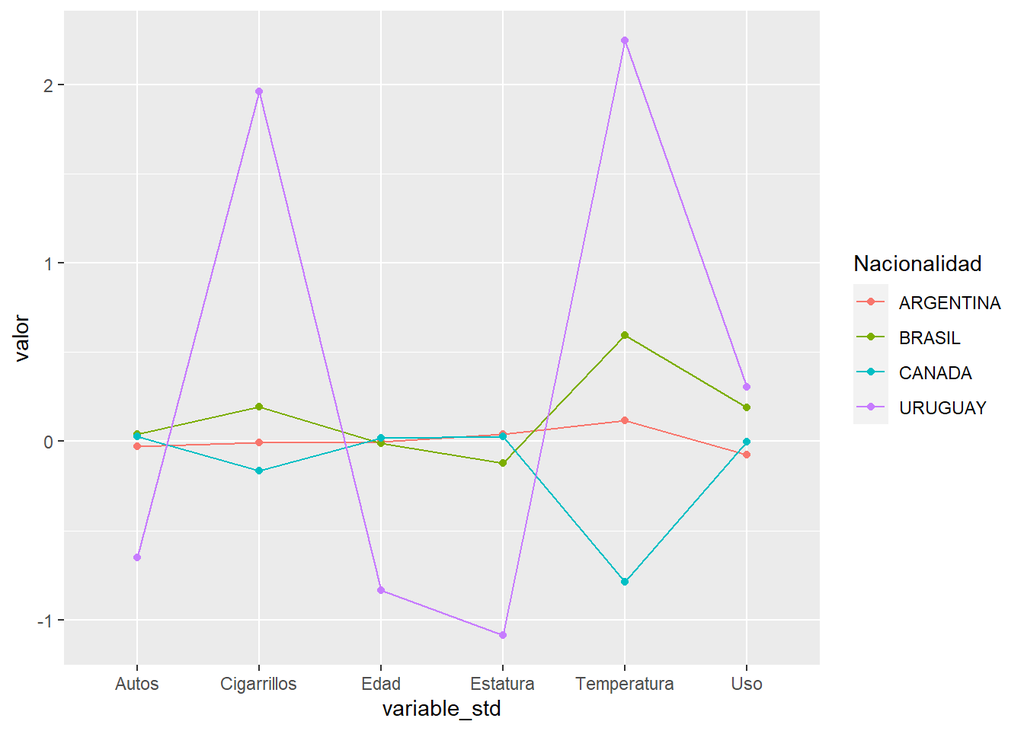

```r
internet %>% select(Nacionalidad,
                    Edad,
                    Estatura,
                    Uso,
                    Temperatura,
                    Autos,
                    Cigarrillos) %>%
  mutate_if(is.numeric, ~scale(.)) %>%
  group_by(Nacionalidad) %>%
  summarize_all(mean) %>%
  pivot_longer(cols = 2:7, values_to = 'valor', names_to = 'variable_std') %>%
  ggplot(aes(x=variable_std, y = valor, group= Nacionalidad, color=Nacionalidad))+
  geom_line()+
  geom_point()
```

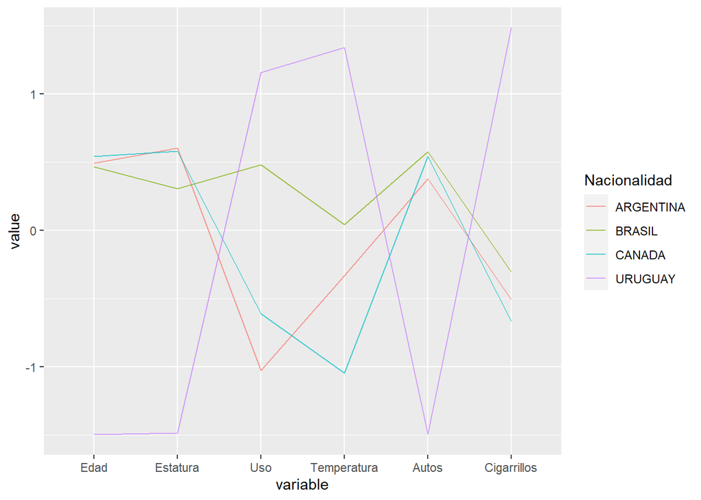

```r
#gráfico de coordenadas paralelas
internet %>% select(Nacionalidad,
                    Edad,
                    Estatura,
                    Uso,
                   Temperatura,
                    Autos,
                    Cigarrillos) %>%
  mutate_if(is.numeric, ~scale(.)) %>%
  group_by(Nacionalidad) %>%
  summarize_all(mean) %>%
  ggparcoord(columns = 2:7,  # Variables on x-axis
             groupColumn = "Nacionalidad", #Variable on y-axis
             alphaLines = 0.7)
```

Gráfico de Coordenadas Paralelas tipico.

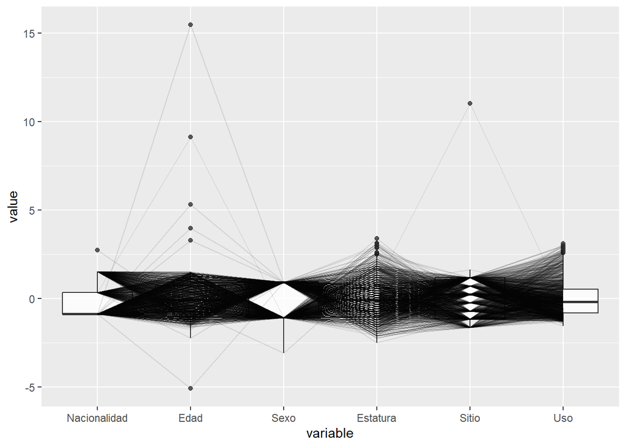

```r
internet %>%
  ggparcoord(columns = 2:7,  alphaLines = 0.1, boxplot = T)
```

### b. Construir la tabla de frecuencias de la variable sexo. ¿Hay algún valor que llame la atención? ¿Qué tipo de error considera que es?

```r
library(summarytools)
```

*Rta: Tabla de Frecuencias para Sexo*

```r
freq(internet$Sexo)
```

```
## Frequencies
## internet$Sexo
## Type: Numeric
##
##               Freq   % Valid   % Valid Cum.   % Total   % Total Cum.
## ----------- ------ --------- -------------- --------- --------------
##           0      1     0.067          0.067     0.067          0.067
##           1    684    45.600         45.667    45.600         45.667
##           2    815    54.333        100.000    54.333        100.000
##        <NA>      0                              0.000        100.000
##       Total   1500   100.000        100.000   100.000        100.000
```

*Rta: Tabla de Frecuencias para Sexo, version rbase*

```r
table(internet$Sexo) #counts the frequency of each unique value or combination of values in one or more categorical variables and presents the counts in a tabular format
```

```
##
##   0   1   2
##   1 684 815
```

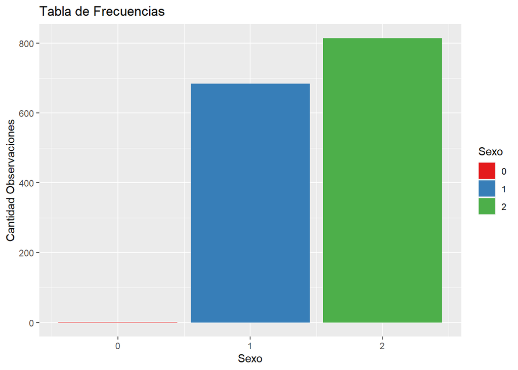

*Rta: Error de tipeo, hay un valor de Sexo = 0*

### c1. Ordenar los datos por la variable Edad. ¿Encontró algún valor extraño? ¿Qué tipo de error puede ser? Idem Construir la tabla de frecuencias de la variable Sitio. ¿Encuentra algún valor que le llame la atención? ¿Qué tipo de error puede ser?

Resumen de Edad:

```r
internet$Edad %>% summary()
```

```
##    Min. 1st Qu.  Median    Mean 3rd Qu.    Max.
##  -44.00   24.00   35.00   36.18   48.00  280.00
```

```r
internet %>%
  group_by(Edad) %>%
  summarise(Frecuencia = n()) %>%
  arrange(-Edad)
```

```
## # A tibble: 59 × 2
##     Edad Frecuencia
##    <dbl>      <int>
##  1   280          1
##  2   180          1
##  3   120          1
##  4    99          1
##  5    88          1
##  6    60          9
##  7    59         29
##  8    58         35
##  9    57         34
## 10    56         29
## # ℹ 49 more rows
```

Para explorar la variable por nacionalidad.

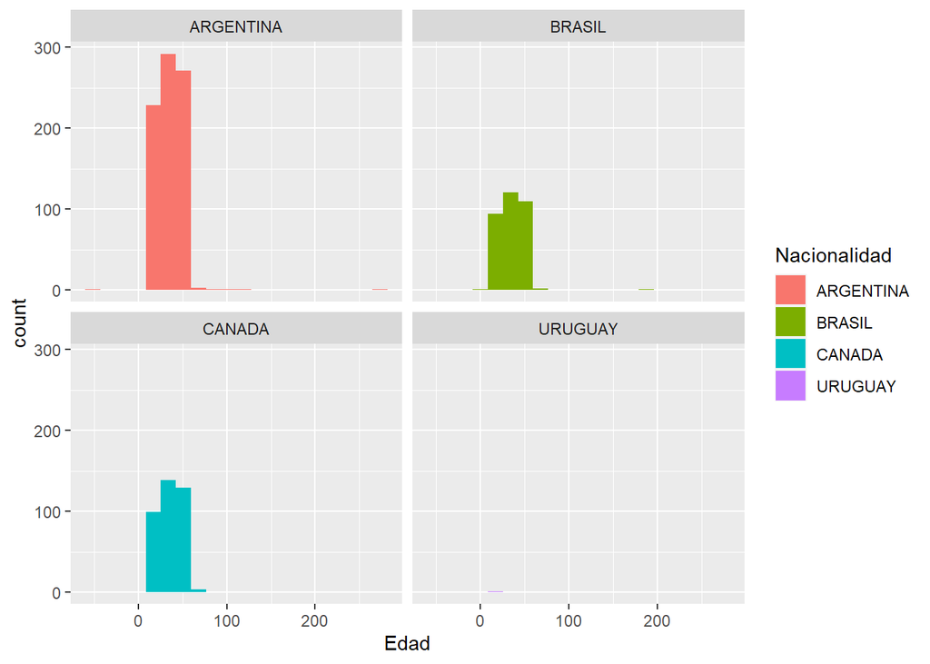

```r
internet %>%
  select(Edad, Nacionalidad) %>%
  ggplot(aes(x=Edad, fill= Nacionalidad))+
  geom_histogram(bins = 20)+
  facet_wrap(~Nacionalidad)
```

```r
internet %>%
  select(Edad) %>%
  mutate( Edad2 = scale(Edad)) %>%
  filter(Edad2< -3 | Edad2 > 3) %>% arrange(Edad)
```

```
## # A tibble: 6 × 2
##    Edad Edad2[,1]
##   <dbl>     <dbl>
## 1   -44     -5.09
## 2    88      3.29
## 3    99      3.98
## 4   120      5.32
## 5   180      9.12
## 6   280     15.5
```

Los valores erroneos pueden ser los siguientes.

```r
internet %>% filter(Edad < 0 | Edad>110) %>% select(Edad)
```

```
## # A tibble: 4 × 1
##    Edad
##   <dbl>
## 1   280
## 2   120
## 3   -44
## 4   180
```

Existen varios registros que indican ocurrencias de edades erroneas, entre ellas:

- Un registro que indica una edad de 120
- Un registro que indica una edad de 180
- Un registro que indica una edad de 280
- Un registro que indica una edad de -44

### c2. Construir la tabla de frecuencias de la variable Sitio. ¿Encuentra algún valor que le llame la atención? ¿Qué tipo de error puede ser?

```r
freq(internet$Sitio)
```

```
## Frequencies
## internet$Sitio
## Type: Numeric
##
##               Freq   % Valid   % Valid Cum.   % Total   % Total Cum.
## ----------- ------ --------- -------------- --------- --------------
##           1    104     6.933          6.933     6.933          6.933
##           2    273    18.200         25.133    18.200         25.133
##           3    172    11.467         36.600    11.467         36.600
##           4    141     9.400         46.000     9.400         46.000
##           5    271    18.067         64.067    18.067         64.067
##           6    140     9.333         73.400     9.333         73.400
##           7    397    26.467         99.867    26.467         99.867
##           8      1     0.067         99.933     0.067         99.933
##          28      1     0.067        100.000     0.067        100.000
##        <NA>      0                              0.000        100.000
##       Total   1500   100.000        100.000   100.000        100.000
```

[output not shown]

A continuacion se realiza la tabla de frecuencias para Sitio incluyendo los nombres de la variable.

```r
internet %>% left_join(sitios, by=c("Sitio"= "id")) %>% select(Sitio.y) %>% freq()
```

```
## Frequencies
## internet$Sitio.y
## Type: Character
##
##                    Freq   % Valid   % Valid Cum.   % Total   % Total Cum.
## ---------------- ------ --------- -------------- --------- --------------
##       buscadores    172     11.48          11.48     11.47          11.47
##             chat    104      6.94          18.42      6.93          18.40
##         deportes    140      9.35          27.77      9.33          27.73
##            email    273     18.22          45.99     18.20          45.93
##           musica    271     18.09          64.09     18.07          64.00
##            otros    397     26.50          90.59     26.47          90.47
##         software    141      9.41         100.00      9.40          99.87
##             <NA>      2                               0.13         100.00
##            Total   1500    100.00         100.00    100.00         100.00
```

```r
internet %>% left_join(sitios, by=c("Sitio"= "id")) %>%
  group_by(Sitio.y) %>%
  count()
```

```
## # A tibble: 8 × 2
## # Groups:   Sitio.y [8]
##   Sitio.y        n
##   <chr>      <int>
## 1 buscadores   172
## 2 chat         104
## 3 deportes     140
## 4 email        273
## 5 musica       271
## 6 otros        397
## 7 software     141
## 8 <NA>           2
```

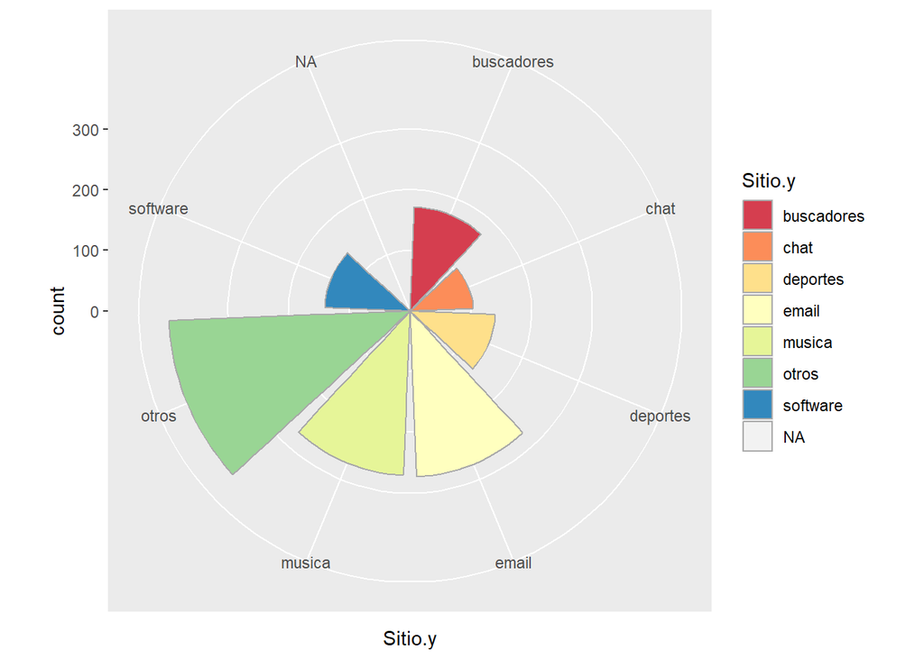

```r
internet %>% left_join(sitios, by=c("Sitio"= "id")) %>%
  ggplot(aes(x=Sitio.y))+
  geom_bar(aes(fill=Sitio.y ), color='darkgrey')+
  coord_polar()+
  scale_fill_brewer(palette = 'Spectral')
```

*Rta: los valores validos son del 1 al 7.*

Existen varios registros que cuyos valores escapan a los valores establecidos para la variable categorica sitio, entre ellos:

- Un registro que indica un valor de 8 (no corresponde a ningun valor esperado para esta variable que solo toma los valores del 1 al 7)
- Un registro que indica un valor de 28 (no corresponde a ningun valor esperado para esta variable que solo toma los valores del 1 al 7)

### d. Proceda de forma similar para las variables Temperatura, Autos y Cigarrillos.

#### 1. Temperatura

Construir la tabla de frecuencias. ¿Encuentra algún valor que le llame la atención? ¿Qué tipo de error puede ser?

Exploramos la variable temperatura de manera descriptiva.

```r
internet$Temperatura %>% summary()
```

```
##    Min. 1st Qu.  Median    Mean 3rd Qu.    Max.
##  -14.00    5.00   11.00   10.97   18.00  131.00
```

Ordenamos los datos y contamos la cantidad de datos en cada registro.

```r
internet %>%
  group_by(Temperatura) %>%
  summarise(Frecuencia = n()) %>%
  arrange(-Temperatura)
```

```
## # A tibble: 54 × 2
##    Temperatura Frecuencia
##          <dbl>      <int>
##  1         131          1
##  2          94          1
##  3          40          1
##  4          36          2
##  5          35          5
##  6          34          9
##  7          33          6
##  8          32         14
##  9          31         10
## 10          30          8
## # ℹ 44 more rows
```

Se realiza un histograma para ver la distribución de la variable.

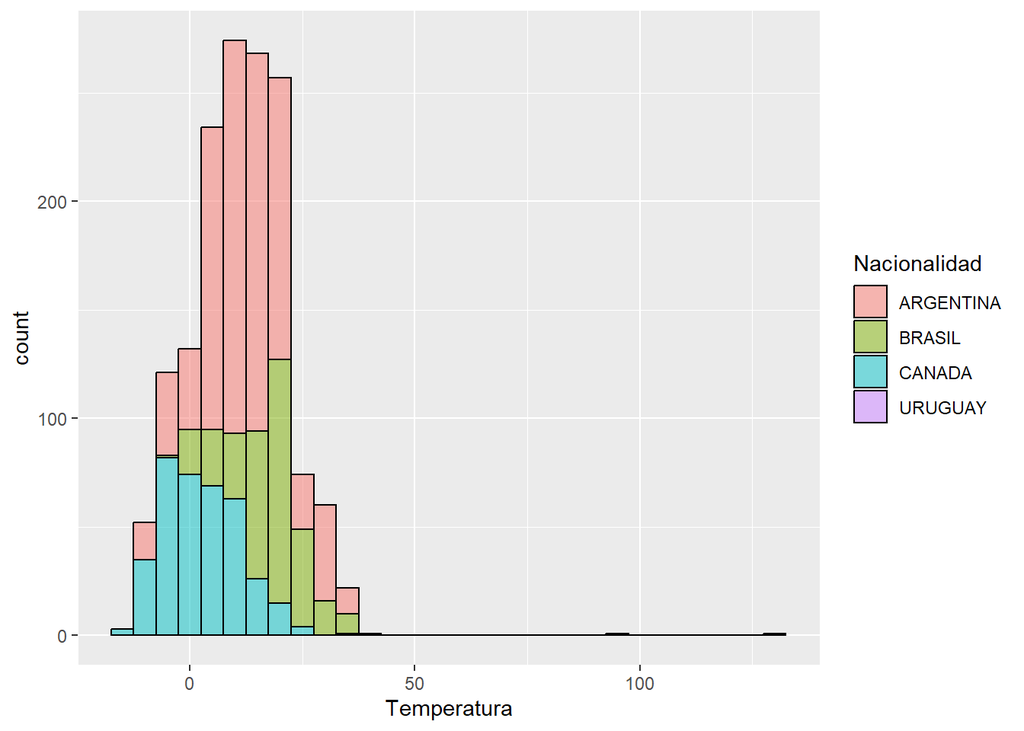

```r
internet %>% ggplot(aes(x=Temperatura, fill=Nacionalidad)) +
  geom_histogram(bins = 30, color='black', alpha=0.5)
```

De la misma manera se explora la variable usando boxplots.

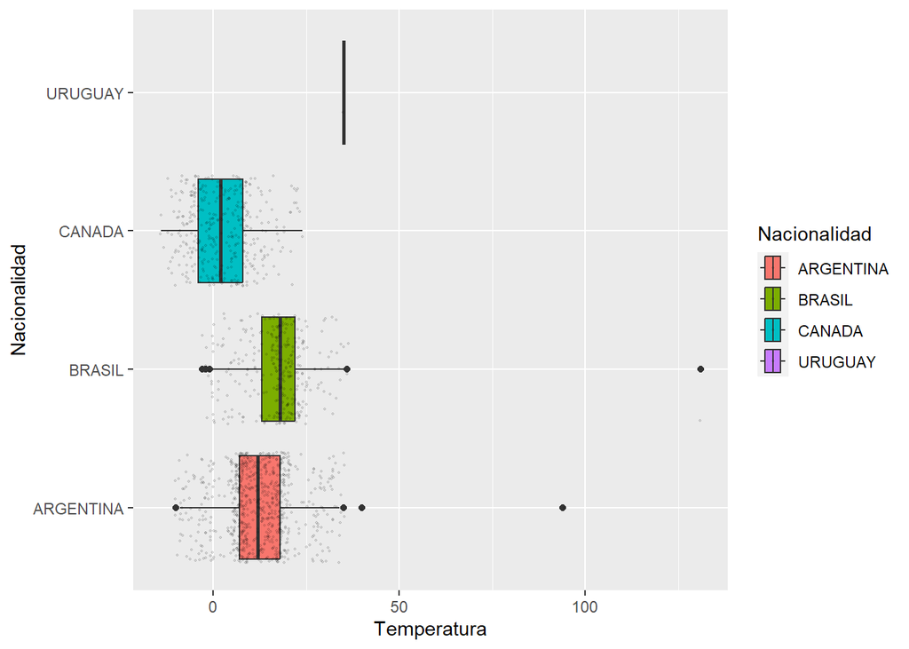

```r
internet %>% ggplot(aes(x=Temperatura, y=Nacionalidad, fill=Nacionalidad))+
  geom_boxplot()+
  geom_jitter(alpha=0.1, size = 0.4)
```

```r
internet %>%
  select(Temperatura) %>%
  mutate( Temperatura2 = scale(Temperatura)) %>%
  filter(Temperatura2< -3 | Temperatura2> 3) %>% arrange(Temperatura)
```

```
## # A tibble: 2 × 2
##   Temperatura Temperatura2[,1]
##         <dbl>            <dbl>
## 1          94             7.76
## 2         131            11.2
```

```r
internet %>% filter(Temperatura > 40) %>% select(Temperatura)
```

```
## # A tibble: 2 × 1
##   Temperatura
##         <dbl>
## 1         131
## 2          94
```

Existen dos registros que cuyos valores escapan a los valores establecidos para la variable temperatura, entre ellos:

- Un registro que indica una temperatura media anual de 94 grados celcius
- Un registro que indica una temperatura media anual de 131 grados celcius

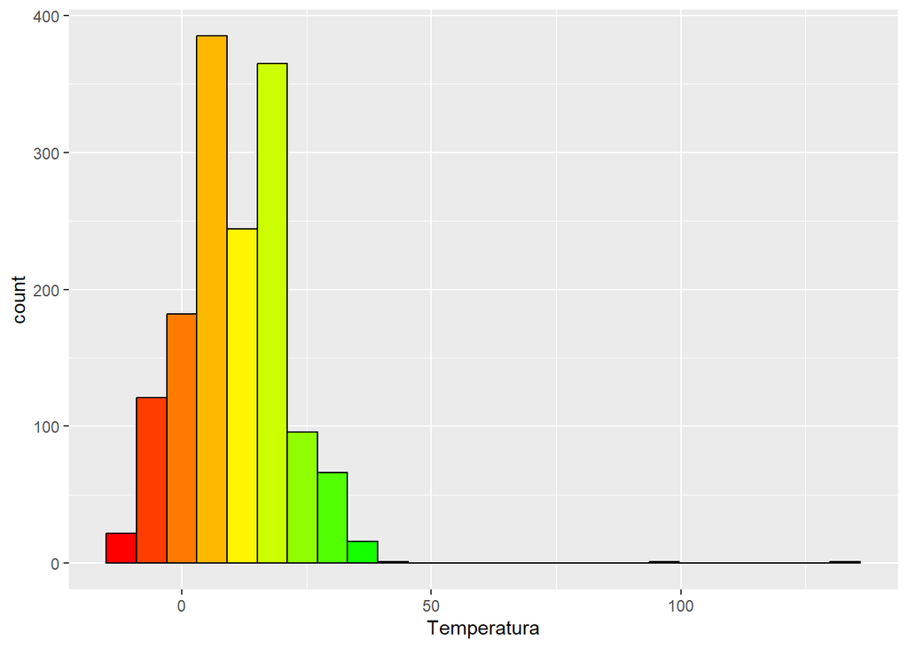

Tabla de Frecuencias para Temperatura

```r
cut_width(internet$Temperatura,5) %>% freq()
```

```
## Frequencies
##
##                       Freq   % Valid   % Valid Cum.   % Total   % Total Cum.
## ------------------- ------ --------- -------------- --------- --------------
##       [-17.5,-12.5]      3     0.200          0.200     0.200          0.200
##        (-12.5,-7.5]     52     3.467          3.667     3.467          3.667
##         (-7.5,-2.5]    121     8.067         11.733     8.067         11.733
##          (-2.5,2.5]    132     8.800         20.533     8.800         20.533
##           (2.5,7.5]    234    15.600         36.133    15.600         36.133
##          (7.5,12.5]    274    18.267         54.400    18.267         54.400
##         (12.5,17.5]    268    17.867         72.267    17.867         72.267
##         (17.5,22.5]    257    17.133         89.400    17.133         89.400
##         (22.5,27.5]     74     4.933         94.333     4.933         94.333
##         (27.5,32.5]     60     4.000         98.333     4.000         98.333
##         (32.5,37.5]     22     1.467         99.800     1.467         99.800
##         (37.5,42.5]      1     0.067         99.867     0.067         99.867
##         (42.5,47.5]      0     0.000         99.867     0.000         99.867
##         (47.5,52.5]      0     0.000         99.867     0.000         99.867
##         (52.5,57.5]      0     0.000         99.867     0.000         99.867
##         (57.5,62.5]      0     0.000         99.867     0.000         99.867
##         (62.5,67.5]      0     0.000         99.867     0.000         99.867
##         (67.5,72.5]      0     0.000         99.867     0.000         99.867
##         (72.5,77.5]      0     0.000         99.867     0.000         99.867
##         (77.5,82.5]      0     0.000         99.867     0.000         99.867
##         (82.5,87.5]      0     0.000         99.867     0.000         99.867
##         (87.5,92.5]      0     0.000         99.867     0.000         99.867
##         (92.5,97.5]      1     0.067         99.933     0.067         99.933
##          (97.5,102]      0     0.000         99.933     0.000         99.933
##           (102,108]      0     0.000         99.933     0.000         99.933
##           (108,112]      0     0.000         99.933     0.000         99.933
##           (112,118]      0     0.000         99.933     0.000         99.933
##           (118,122]      0     0.000         99.933     0.000         99.933
##           (122,128]      0     0.000         99.933     0.000         99.933
##           (128,132]      1     0.067        100.000     0.067        100.000
##                <NA>      0                              0.000        100.000
##               Total   1500   100.000        100.000   100.000        100.000
```

#### 2. Autos

```r
internet$Autos %>% summary()
```

```
##    Min. 1st Qu.  Median    Mean 3rd Qu.    Max.
##     0.0    49.0    99.5   100.9   147.0  2680.0
```

```r
internet %>%
  group_by(Autos) %>%
  summarise(Frecuencia = n()) %>%
  arrange(-Autos)
```

```
## # A tibble: 200 × 2
##    Autos Frecuencia
##    <dbl>      <int>
##  1  2680          1
##  2   200          7
##  3   199          7
##  4   198          6
##  5   197          9
##  6   196          5
##  7   195          8
##  8   194          8
##  9   193          7
## 10   192          7
## # ℹ 190 more rows
```

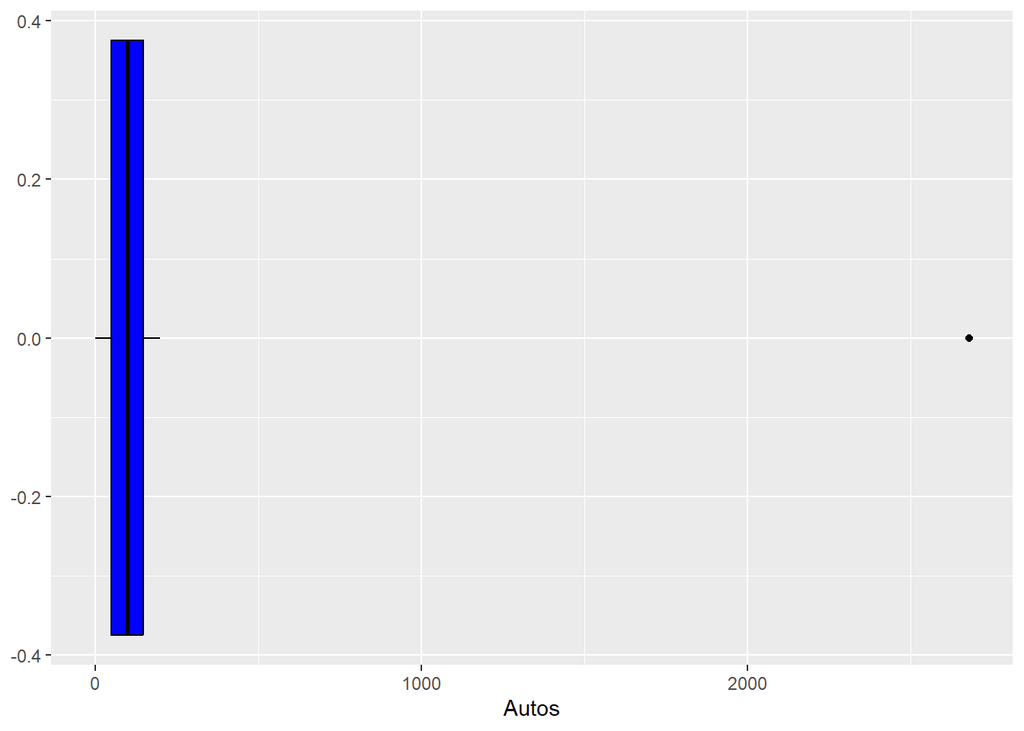

```r
internet %>% select(Autos) %>% ggplot(aes(x=Autos))+geom_boxplot(fill = 'blue', color='black')
```

```r
internet %>% filter(Autos >200)
```

```
## # A tibble: 1 × 10
##      ID Nacionalidad  Edad  Sexo Estatura Sitio   Uso Temperatura Autos
##   <dbl> <fct>        <dbl> <dbl>    <dbl> <dbl> <dbl>       <dbl> <dbl>
## 1   836 CANADA          37     1      1.6     5    65          11  2680
## # ℹ 1 more variable: Cigarrillos <dbl>
```

¿Encuentra algún valor que le llame la atención? ¿Qué tipo de error puede ser?

Existe un registro que indica la presencia de 2680 autos en una unica manzana, lo cual indica un claro error en el valor ingresado.

#### 3. Cigarrillos

```r
internet$Cigarrillos %>% summary()
```

```
##    Min. 1st Qu.  Median    Mean 3rd Qu.    Max.
##   0.000   0.000   2.000   3.049   4.000 100.000
```

```r
internet %>% group_by(Cigarrillos) %>% summarise(Frecuencia = n()) %>% arrange(-Cigarrillos)
```

```
## # A tibble: 29 × 2
##    Cigarrillos Frecuencia
##          <dbl>      <int>
##  1         100          1
##  2          75          1
##  3          30          1
##  4          29          1
##  5          28          1
##  6          26          2
##  7          24          1
##  8          23          1
##  9          20          8
## 10          19          3
## # ℹ 19 more rows
```

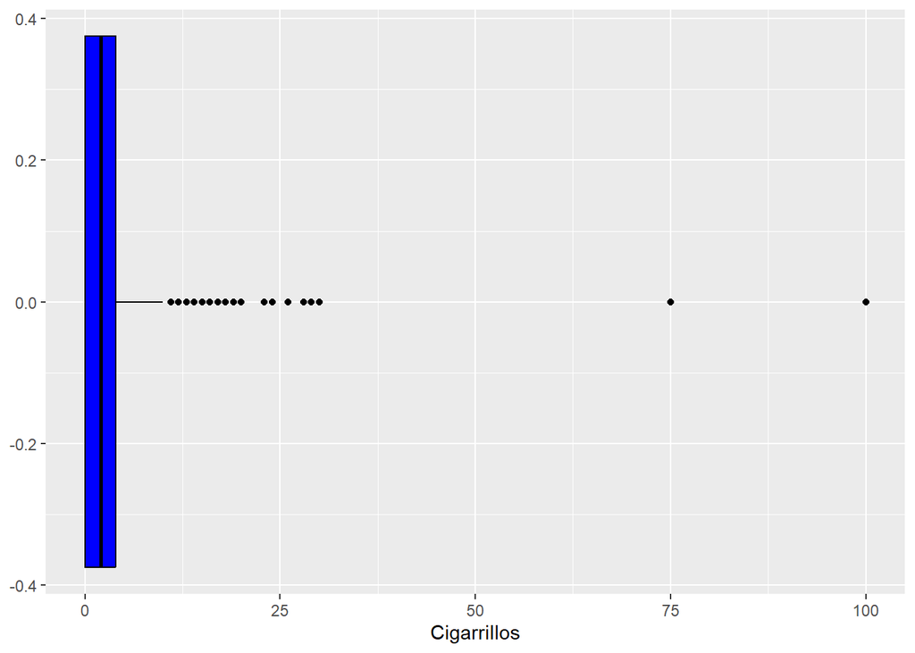

```r
internet %>% select(Cigarrillos) %>% ggplot(aes(x=Cigarrillos))+geom_boxplot(fill = 'blue', color='black')
```

```r
internet %>% filter(Cigarrillos >30)
```

```
## # A tibble: 2 × 10
##      ID Nacionalidad  Edad  Sexo Estatura Sitio   Uso Temperatura Autos
##   <dbl> <fct>        <dbl> <dbl>    <dbl> <dbl> <dbl>       <dbl> <dbl>
## 1  1365 ARGENTINA       88     2     1.62     7     0          32     2
## 2  1490 ARGENTINA       99     2     1.66     7    -2          40     0
## # ℹ 1 more variable: Cigarrillos <dbl>
```

Existen varios registros que cuyos valores son extremadamente elevados al punto de considerarse altamente improbables y erroneos:

- Un individuo que consume 100 cicarrillos mientras utiliza internet
- Un individuo que consume 75 cicarrillos mientras utiliza internet

#### ¿Encuentra algún valor que le llame la atención? ¿Qué tipo de error puede ser?

Existen varios registros que cuyos valores son extremadamente elevados al punto de considerarse altamente improbables y erroneos:

- Un individuo que consume 100 cicarrillos mientras utiliza internet
- Un individuo que consume 75 cicarrillos mientras utiliza internet

#### e. Elimine de la base los valores que no son posibles y que seguramente corresponde a un error de tipeo. Detalle valores/registros que le hayan llamado la atención pero no deban ser eliminados necesariamente.

Errores de Tipeo.

##### Sexo

- Sexo = 0

##### Edad

- Un registro que indica una edad de 120
- Un registro que indica una edad de 180
- Un registro que indica una edad de 280
- Un registro que indica una edad de -44

##### Sitio

- Un registro que indica un valor de 8 (no corresponde a ningun valor esperado para esta variable que solo toma los valores del 1 al 7)
- Un registro que indica un valor de 28 (no corresponde a ningun valor esperado para esta variable que solo toma los valores del 1 al 7)

##### Temperatura

- Un registro que indica una temperatura media anual de 94 grados celcius
- Un registro que indica una temperatura media anual de 131 grados celcius

##### Autos

- Existe un registro que indica la presencia de 2680 autos en una unica manzana, lo cual indica un claro error en el valor ingresado.

##### Cigarrilos

- Un individuo que consume 100 cicarrillos mientras utiliza internet
- Un individuo que consume 75 cicarrillos mientras utiliza internet

#### e.2. Eliminar Datos Erroneos o Imposibles

```r
internet %>% filter(Sexo!=0,
                    Edad>0, Edad<100,
                    between(Sitio, 1,7),
                    Temperatura<50,
                    Autos<500,
                    Cigarrillos<50)
```

```
## # A tibble: 1,488 × 10
##       ID Nacionalidad  Edad  Sexo Estatura Sitio   Uso Temperatura Autos
##    <dbl> <fct>        <dbl> <dbl>    <dbl> <dbl> <dbl>       <dbl> <dbl>
##  1     1 ARGENTINA       17     2     1.55     2   105           9   111
##  2     2 ARGENTINA       19     1     1.89     3   106          18   121
##  3     3 ARGENTINA       28     1     1.57     2   106           6   169
##  4     4 ARGENTINA       47     1     1.55     6   229          10    89
##  5     5 CANADA          27     2     1.61     7    33          -3   114
##  6     6 ARGENTINA       17     1     1.81     1    89          16    89
##  7     7 ARGENTINA       54     1     1.66     7   185          18   115
##  8     8 ARGENTINA       11     2     1.69     2   220          15    65
##  9     9 ARGENTINA       27     2     1.57     5   210          19   107
## 10    10 ARGENTINA       40     1     1.56     4   196          15    12
## # ℹ 1,478 more rows
## # ℹ 1 more variable: Cigarrillos <dbl>
```

#### f. ¿Para cuáles de las variables tiene sentido calcular la media? ¿Y la me- diana?¿Para cuáles de las variables tiene sentido calcular la media? ¿Y la mediana?

Tiene sentido calcular media y mediana paraquellas variables que son numericas, no asi para las categoricas.

```r
sexo = data.frame(id=c(1,2, -1), Sexo=c('Masculino', 'Femenino', 'Error'))
```

```r
internet %>%
  left_join(sitios, by=c("Sitio"= "id")) %>%
  left_join(sexo, by=c('Sexo'='id')) %>%
  select(-c(Sexo, Sitio)) %>%
  glimpse()
```

```
## Rows: 1,500
## Columns: 10
## $ ID           <dbl> 1, 2, 3, 4, 5, 6, 7, 8, 9, 10, 11, 12, 13, 14, 15, 16, 17…
## $ Nacionalidad <fct> ARGENTINA, ARGENTINA, ARGENTINA, ARGENTINA, CANADA, ARGEN…
## $ Edad         <dbl> 17, 19, 28, 47, 27, 17, 54, 11, 27, 40, 31, 35, 18, 58, 3…
## $ Estatura     <dbl> 1.55, 1.89, 1.57, 1.55, 1.61, 1.81, 1.66, 1.69, 1.57, 1.5…
## $ Uso          <dbl> 105, 106, 106, 229, 33, 89, 185, 220, 210, 196, 42, 82, 1…
## $ Temperatura  <dbl> 9, 18, 6, 10, -3, 16, 18, 15, 19, 15, -2, 15, 5, 18, 15, …
## $ Autos        <dbl> 111, 121, 169, 89, 114, 89, 115, 65, 107, 12, 133, 96, 14…
## $ Cigarrillos  <dbl> 6, 6, 4, 9, 0, 4, 1, 23, 0, 3, 2, 0, 0, 0, 4, 12, 2, 0, 5…
## $ Sitio.y      <chr> "email", "buscadores", "email", "deportes", "otros", "cha…
## $ Sexo.y       <chr> "Femenino", "Masculino", "Masculino", "Masculino", "Femen…
```

#### g ¿Cuáles de las variables le parecen simétricas a partir de estos resúmenes? Confirme estas observaciones mediante un boxplot.

Las variables con mayor simetria son las correspondientes a:

- Autos
- Edad

[figure not shown]

```r
#install.packages("ggridges")
```

```r
library(ggridges)
```

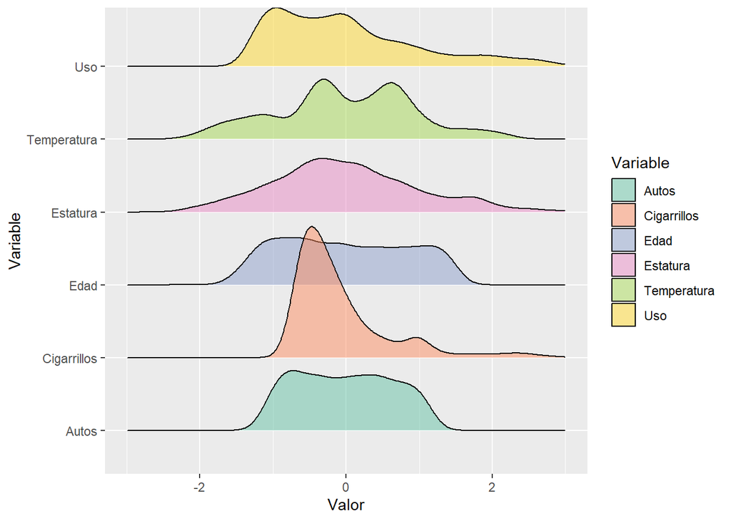

```r
internet %>% select(Nacionalidad,
                    Edad,
                    Estatura,
                    Uso,
                    Temperatura,
                    Autos,
                    Cigarrillos) %>%
  mutate_if(is.numeric, ~scale(.)) %>%
  pivot_longer(names_to ="Variable", values_to = 'Valor', cols = 2:7) %>%
  ggplot(aes(x=Valor, y= Variable, fill=Variable))+
  geom_density_ridges(alpha=0.5)+
  scale_fill_brewer(palette = "Set2")+
  xlim(-3,3)
```

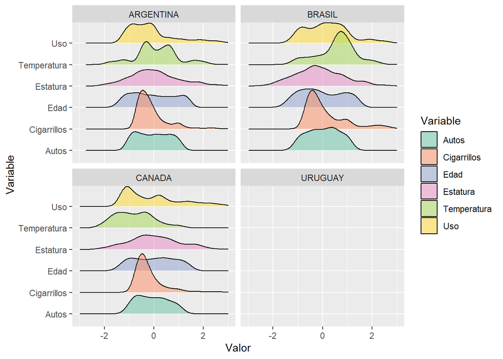

```r
internet %>% select(Nacionalidad,
                    Edad,
                    Estatura,
                    Uso,
                    Temperatura,
                    Autos,
                    Cigarrillos) %>%
  mutate_if(is.numeric, ~scale(.)) %>%
  pivot_longer(names_to ="Variable", values_to = 'Valor', cols = 2:7) %>%
  ggplot(aes(x=Valor, y= Variable, fill=Variable))+
  geom_density_ridges(alpha=0.5)+
  scale_fill_brewer(palette = "Set2")+
  xlim(-3,3)+
  facet_wrap(~Nacionalidad)
```

#### (h) Calcular la desviación intercuartil y detectar presencia de valores salvajes moderados y severos.

Funcion para deteccion de valores atipicos

```r
select_column <- function(dataframe, column_name) {
  if (column_name %in% names(dataframe)) {
    a = dataframe[[column_name]]

    q3 = quantile(a, 0.75)[[1]]
    q1 = quantile(a, 0.25)[[1]]
    riq = q3-q1
    li_salvaje = (q1 - 1.5 * riq)
    ls_salvaje = (q3 + 1.5 * riq )
    li_severo = (q1 - 3 * riq)
    ls_severo = (q3 + 3 * riq )
    df = data.frame(Lim_outliers = c('Li_Salvaje','Ls_Salvaje', 'Li_Severo','Ls_Severo'),
                    valores = c(li_salvaje, ls_salvaje, li_severo, ls_severo ))

    tolerance = 1e-6
    df2 = internet %>% mutate(Categoria = case_when(a < li_salvaje | a > ls_salvaje + tolerance ~ "Salvaje",
                                         a < li_severo | a > ls_severo + tolerance ~ "Severo",
                                         TRUE ~ "Normal")) %>%
      filter(Categoria != 'Normal') %>%
      select(column_name, Categoria)
    result = list(valores_criticos = df,
                  df_filtrado = df2)
    return(result)
  } else {
    stop("El nombre de la columna proporcionado no se encuentra en el dataframe.")
  }
}
```

##### Edad

```r
select_column(internet, 'Edad')$valores_criticos
```

```
##   Lim_outliers valores
## 1   Li_Salvaje     -12
## 2   Ls_Salvaje      84
## 3    Li_Severo     -48
## 4    Ls_Severo     120
```

```r
select_column(internet, 'Edad')$df_filtrado
```

```
## # A tibble: 6 × 2
##    Edad Categoria
##   <dbl> <chr>
## 1   280 Salvaje
## 2   120 Salvaje
## 3   -44 Salvaje
## 4    88 Salvaje
## 5   180 Salvaje
## 6    99 Salvaje
```

#### Estatura

```r
select_column(internet, 'Estatura')$valores_criticos
```

```
##   Lim_outliers valores
## 1   Li_Salvaje    1.46
## 2   Ls_Salvaje    1.86
## 3    Li_Severo    1.31
## 4    Ls_Severo    2.01
```

```r
select_column(internet, 'Estatura')$df_filtrado
```

```
## # A tibble: 17 × 2
##    Estatura Categoria
##       <dbl> <chr>
##  1     1.89 Salvaje
##  2     1.89 Salvaje
##  3     1.91 Salvaje
##  4     1.87 Salvaje
##  5     1.89 Salvaje
##  6     1.87 Salvaje
##  7     1.87 Salvaje
##  8     1.87 Salvaje
##  9     1.87 Salvaje
## 10     1.9  Salvaje
## 11     1.91 Salvaje
## 12     1.91 Salvaje
## 13     1.93 Salvaje
## 14     1.9  Salvaje
## 15     1.87 Salvaje
## 16     1.9  Salvaje
## 17     1.9  Salvaje
```

##### Uso

```r
select_column(internet, 'Uso')$valores_criticos
```

```
##   Lim_outliers valores
## 1   Li_Salvaje  -110.5
## 2   Ls_Salvaje   309.5
## 3    Li_Severo  -268.0
## 4    Ls_Severo   467.0
```

```r
select_column(internet, 'Uso')$df_filtrado
```

```
## # A tibble: 27 × 2
##      Uso Categoria
##    <dbl> <chr>
##  1   330 Salvaje
##  2   320 Salvaje
##  3   320 Salvaje
##  4   318 Salvaje
##  5   314 Salvaje
##  6   320 Salvaje
##  7   340 Salvaje
##  8   340 Salvaje
##  9   312 Salvaje
## 10   341 Salvaje
## # ℹ 17 more rows
```

##### Temperatura

```r
select_column(internet, 'Temperatura')$valores_criticos
```

```
##   Lim_outliers valores
## 1   Li_Salvaje   -14.5
## 2   Ls_Salvaje    37.5
## 3    Li_Severo   -34.0
## 4    Ls_Severo    57.0
```

```r
select_column(internet, 'Temperatura')$df_filtrado
```

```
## # A tibble: 3 × 2
##   Temperatura Categoria
##         <dbl> <chr>
## 1         131 Salvaje
## 2          94 Salvaje
## 3          40 Salvaje
```

##### Autos

```r
select_column(internet, 'Autos')$valores_criticos
```

```
##   Lim_outliers valores
## 1   Li_Salvaje     -98
## 2   Ls_Salvaje     294
## 3    Li_Severo    -245
## 4    Ls_Severo     441
```

```r
select_column(internet, 'Autos')$df_filtrado
```

```
## # A tibble: 1 × 2
##   Autos Categoria
##   <dbl> <chr>
## 1  2680 Salvaje
```

##### Cigarillos

```r
select_column(internet, 'Cigarrillos')$valores_criticos
```

```
##   Lim_outliers valores
## 1   Li_Salvaje      -6
## 2   Ls_Salvaje      10
## 3    Li_Severo     -12
## 4    Ls_Severo      16
```

```r
select_column(internet, 'Cigarrillos')$df_filtrado
```

```
## # A tibble: 83 × 2
##    Cigarrillos Categoria
##          <dbl> <chr>
##  1          23 Salvaje
##  2          12 Salvaje
##  3          13 Salvaje
##  4          13 Salvaje
##  5          14 Salvaje
##  6          14 Salvaje
##  7          15 Salvaje
##  8          28 Salvaje
##  9          11 Salvaje
## 10          15 Salvaje
## # ℹ 73 more rows
```

```r
k = 10 * log(nrow(internet))#dixo
k2 = 1 + 3.322 * log(nrow(internet))#strudges
```

```r
internet %>% select(Temperatura) %>%
  mutate(intervalos = cut(Temperatura, breaks  = k2)) %>%
  group_by(intervalos) %>%
  summarise(fi = n()) %>%
  mutate(f = fi / sum(fi) * 100)
```

```
## # A tibble: 12 × 3
##    intervalos      fi       f
##    <fct>        <int>   <dbl>
##  1 (-14.1,-8.2]    40  2.67
##  2 (-8.2,-2.4]    136  9.07
##  3 (-2.4,3.4]     149  9.93
##  4 (3.4,9.2]      385 25.7
##  5 (9.2,15]       244 16.3
##  6 (15,20.8]      334 22.3
##  7 (20.8,26.6]    114  7.6
##  8 (26.6,32.4]     73  4.87
##  9 (32.4,38.2]     22  1.47
## 10 (38.2,44]        1  0.0667
## 11 (90.4,96.2]      1  0.0667
## 12 (125,131]        1  0.0667
```

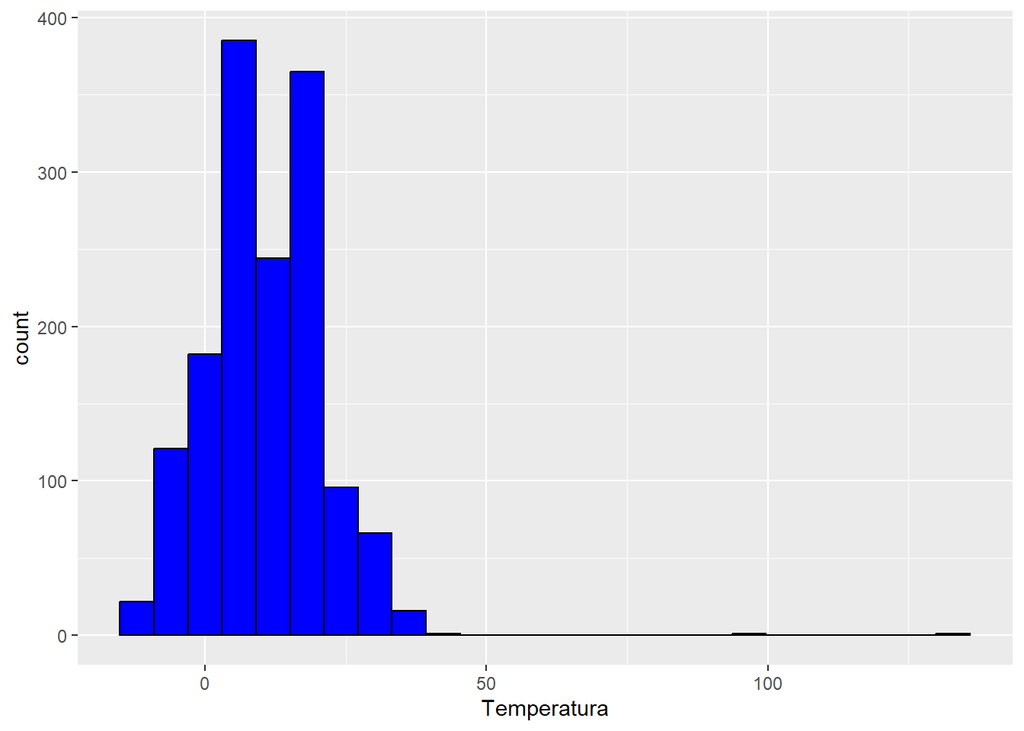

```r
internet %>% select(Temperatura) %>% ggplot(aes(x=Temperatura))+
  geom_histogram(bins = round(k2), fill = 'blue', color='black')
```

```r
internet$Autos %>% summary()
```

```
##    Min. 1st Qu.  Median    Mean 3rd Qu.    Max.
##     0.0    49.0    99.5   100.9   147.0  2680.0
```

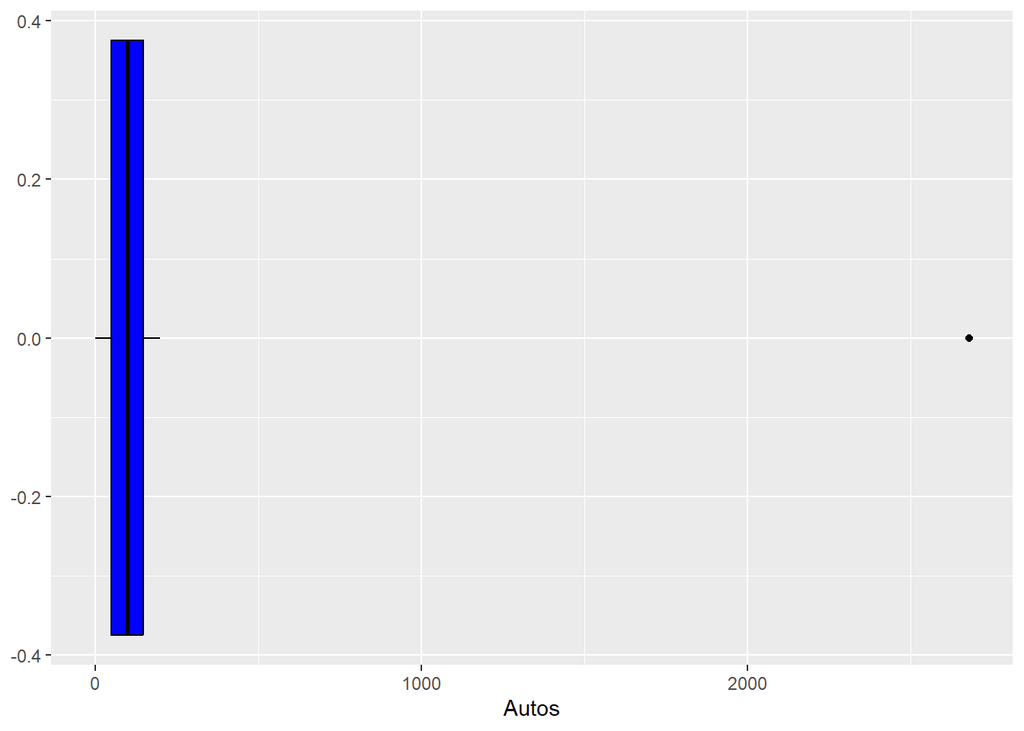

```r
internet %>% select(Autos) %>% ggplot(aes(x=Autos))+
  geom_boxplot(fill = 'blue', color='black')
```

```r
internet %>% select(Autos) %>%
  mutate(intervalos = cut(Autos, breaks  = k)) %>%
  group_by(intervalos) %>%
  summarise(fi = n()) %>%
  mutate(f = fi / sum(fi) * 100)
```

```
## # A tibble: 7 × 3
##   intervalos             fi       f
##   <fct>               <int>   <dbl>
## 1 (-2.68,36.7]          264 17.6
## 2 (36.7,73.4]           310 20.7
## 3 (73.4,110]            273 18.2
## 4 (110,147]             276 18.4
## 5 (147,184]             259 17.3
## 6 (184,220]             117  7.8
## 7 (2.64e+03,2.68e+03]     1  0.0667
```

```r
internet %>% summary()
```

```
##        ID            Nacionalidad      Edad             Sexo
##  Min.   :   1.0   ARGENTINA:799   Min.   :-44.00   Min.   :0.000
##  1st Qu.: 375.8   BRASIL   :329   1st Qu.: 24.00   1st Qu.:1.000
##  Median : 750.5   CANADA   :371   Median : 35.00   Median :2.000
##  Mean   : 750.5   URUGUAY  :  1   Mean   : 36.18   Mean   :1.543
##  3rd Qu.:1125.2                   3rd Qu.: 48.00   3rd Qu.:2.000
##  Max.   :1500.0                   Max.   :280.00   Max.   :2.000
##     Estatura         Sitio             Uso         Temperatura
##  Min.   :1.470   Min.   : 1.000   Min.   :-10.0   Min.   :-14.00
##  1st Qu.:1.610   1st Qu.: 2.000   1st Qu.: 47.0   1st Qu.:  5.00
##  Median :1.660   Median : 5.000   Median : 97.0   Median : 11.00
##  Mean   :1.665   Mean   : 4.493   Mean   :110.3   Mean   : 10.97
##  3rd Qu.:1.710   3rd Qu.: 7.000   3rd Qu.:152.0   3rd Qu.: 18.00
##  Max.   :1.930   Max.   :28.000   Max.   :350.0   Max.   :131.00
##      Autos         Cigarrillos
##  Min.   :   0.0   Min.   :  0.000
##  1st Qu.:  49.0   1st Qu.:  0.000
##  Median :  99.5   Median :  2.000
##  Mean   : 100.9   Mean   :  3.049
##  3rd Qu.: 147.0   3rd Qu.:  4.000
##  Max.   :2680.0   Max.   :100.000
```

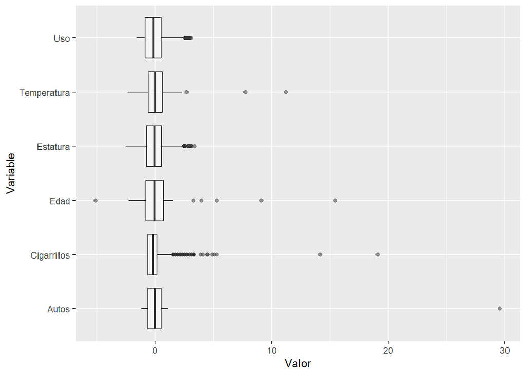

```r
internet %>% select(Nacionalidad,
                    Edad,
                    Estatura,
                    Uso,
                    Temperatura,
                    Autos,
                    Cigarrillos) %>%
  mutate_if(is.numeric, ~scale(.)) %>%
  pivot_longer(names_to ="Variable", values_to = 'Valor', cols = 2:7) %>%
  ggplot(aes(x=Valor, y= Variable))+
  geom_boxplot(alpha=0.5)
```

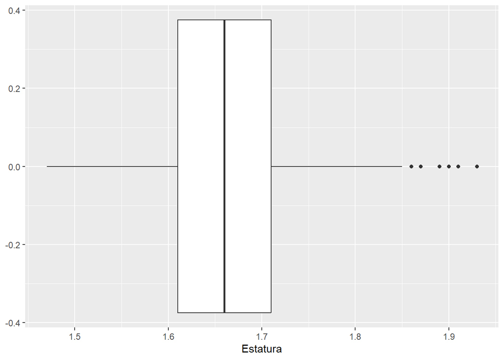

```r
ggplot(internet, aes(x=Estatura)) + geom_boxplot()
```

```r
# q3 = quantile(internet$Estatura, 0.75)
# q1 = quantile(internet$Estatura, 0.25)
# riq = IQR(internet$Estatura)
# #1.5 veces es salvaje
# #3 veces es severo
#
# li_salvaje = (q1- 1.5 * riq)[[1]]
# ls_salvaje = as.numeric(q3 +1.5 * riq )
#
# li_severo = (q1- 3 * riq)[[1]]
# ls_severo = (q3 +3 * riq )[[1]]
```

## Ejercicio 3

Base de datos: Se han registrado para 49 gorriones las siguientes variables zoo-métricas: - a) Largo total - b) Extensión alar - c) Largo del pico y cabeza - d) Largo del húmero - e) Largo de la quilla del esternón - f) Sobrevida (1) Si, (-1) No

```r
gorriones <- read_excel("gorriones.xlsx")
```

```r
gorriones %>% head(3)
```

```
## # A tibble: 3 × 7
##   pajaro largototal extension cabeza humero esternon sobrevida
##    <dbl>      <dbl>     <dbl>  <dbl>  <dbl>    <dbl>     <dbl>
## 1      1        156       245   31.6   18.5     20.5         1
## 2      2        154       240   30.4   17.9     19.6         1
## 3      3        153       240   31     18.4     20.6         1
```

```r
gorriones = gorriones %>% mutate(sobrevida = case_when(sobrevida == 1 ~ "Si",
                                           sobrevida == -1 ~"No"),
                                 sobrevida = as.factor(sobrevida))
gorriones
```

```
## # A tibble: 49 × 7
##    pajaro largototal extension cabeza humero esternon sobrevida
##     <dbl>      <dbl>     <dbl>  <dbl>  <dbl>    <dbl> <fct>
##  1      1        156       245   31.6   18.5     20.5 Si
##  2      2        154       240   30.4   17.9     19.6 Si
##  3      3        153       240   31     18.4     20.6 Si
##  4      4        153       236   30.9   17.7     20.2 Si
##  5      5        155       243   31.5   18.6     20.3 Si
##  6      6        163       247   32     19       20.9 Si
##  7      7        157       238   30.9   18.4     20.2 Si
##  8      8        155       239   32.8   18.6     21.2 Si
##  9      9        164       248   32.7   19.1     21.1 Si
## 10     10        158       238   31     18.8     22   Si
## # ℹ 39 more rows
```

```r
gorriones %>% summary()
```

```
##      pajaro     largototal    extension         cabeza          humero
##  Min.   : 1   Min.   :152   Min.   :230.0   Min.   :30.10   Min.   :17.20
##  1st Qu.:13   1st Qu.:155   1st Qu.:238.0   1st Qu.:30.90   1st Qu.:18.10
##  Median :25   Median :158   Median :242.0   Median :31.50   Median :18.50
##  Mean   :25   Mean   :158   Mean   :241.3   Mean   :31.46   Mean   :18.45
##  3rd Qu.:37   3rd Qu.:161   3rd Qu.:245.0   3rd Qu.:32.00   3rd Qu.:18.80
##  Max.   :49   Max.   :165   Max.   :252.0   Max.   :33.40   Max.   :19.80
##     esternon     sobrevida
##  Min.   :18.60   No:28
##  1st Qu.:20.20   Si:21
##  Median :20.70
##  Mean   :20.83
##  3rd Qu.:21.50
##  Max.   :23.10
```

### (a) Indicar en cada caso de que tipo de variable se trata. Pajaro : ID, Sobrevida : Factor

```r
str(gorriones)
```

```
## tibble [49 × 7] (S3: tbl_df/tbl/data.frame)
##  $ pajaro    : num [1:49] 1 2 3 4 5 6 7 8 9 10 ...
##  $ largototal: num [1:49] 156 154 153 153 155 163 157 155 164 158 ...
##  $ extension : num [1:49] 245 240 240 236 243 247 238 239 248 238 ...
##  $ cabeza    : num [1:49] 31.6 30.4 31 30.9 31.5 32 30.9 32.8 32.7 31 ...
##  $ humero    : num [1:49] 18.5 17.9 18.4 17.7 18.6 19 18.4 18.6 19.1 18.8 ...
##  $ esternon  : num [1:49] 20.5 19.6 20.6 20.2 20.3 20.9 20.2 21.2 21.1 22 ...
##  $ sobrevida : Factor w/ 2 levels "No","Si": 2 2 2 2 2 2 2 2 2 2 ...
```

Largototal, extension, cabeza, humero, esternon son variables continuas (mediciones) por su parte sobrevida es categórica (la vamos a considerar un factor).

### (b) Confeccionar un informe para cada variable( univariado). https://cran.r-project.org/web/packages/summarytools/vignettes/introduction.html

```r
library(summarytools)
```

```r
gorriones %>% summary()
```

```
##      pajaro     largototal    extension         cabeza          humero
##  Min.   : 1   Min.   :152   Min.   :230.0   Min.   :30.10   Min.   :17.20
##  1st Qu.:13   1st Qu.:155   1st Qu.:238.0   1st Qu.:30.90   1st Qu.:18.10
##  Median :25   Median :158   Median :242.0   Median :31.50   Median :18.50
##  Mean   :25   Mean   :158   Mean   :241.3   Mean   :31.46   Mean   :18.45
##  3rd Qu.:37   3rd Qu.:161   3rd Qu.:245.0   3rd Qu.:32.00   3rd Qu.:18.80
##  Max.   :49   Max.   :165   Max.   :252.0   Max.   :33.40   Max.   :19.80
##     esternon     sobrevida
##  Min.   :18.60   No:28
##  1st Qu.:20.20   Si:21
##  Median :20.70
##  Mean   :20.83
##  3rd Qu.:21.50
##  Max.   :23.10
```

```r
descr(gorriones)
```

```
## Non-numerical variable(s) ignored: sobrevida
```

```
## Descriptive Statistics
## gorriones
## N: 49
##
##                     cabeza   esternon   extension   humero   largototal   pajaro
## ----------------- -------- ---------- ----------- -------- ------------ --------
##              Mean    31.46      20.83      241.33    18.45       157.98    25.00
##           Std.Dev     0.79       0.99        5.07     0.54         3.65    14.29
##               Min    30.10      18.60      230.00    17.20       152.00     1.00
##                Q1    30.90      20.20      238.00    18.10       155.00    13.00
##            Median    31.50      20.70      242.00    18.50       158.00    25.00
##                Q3    32.00      21.50      245.00    18.80       161.00    37.00
##               Max    33.40      23.10      252.00    19.80       165.00    49.00
##               MAD     0.89       0.89        5.93     0.44         4.45    17.79
##               IQR     1.10       1.30        7.00     0.70         6.00    24.00
##                CV     0.03       0.05        0.02     0.03         0.02     0.57
##          Skewness     0.37       0.23       -0.13    -0.09         0.14     0.00
##       SE.Skewness     0.34       0.34        0.34     0.34         0.34     0.34
##          Kurtosis    -0.61      -0.37       -0.69     0.05        -1.20    -1.27
##           N.Valid    49.00      49.00       49.00    49.00        49.00    49.00
##         Pct.Valid   100.00     100.00      100.00   100.00       100.00   100.00
```

### (c) Realizar en el caso que corresponda un histograma. Ensayar el número de intervalos que conviene en cada variable, indicar si utiliza algún criterio.

Se calcularon los valores de k (numero de bins en un histograma).

```r
k = 10 * log(nrow(gorriones))#dixo
k2 = 1 + 3.322 * log(nrow(gorriones))#strudges
```

```r
print(c(k, k2))
```

```
## [1] 38.91820 13.92863
```

Tambien se calculó el ancho del bin para cada variable.

```r
gorriones %>% select(-c(sobrevida, pajaro)) %>%
  pivot_longer(cols=1:5,names_to = "variable", values_to = "valor") %>%
  group_by(variable) %>%
  summarise(sd = sd(valor), .groups = "drop") %>%
  mutate(hbind = sd * nrow(gorriones)**-(1/3))
```

```
## # A tibble: 5 × 3
##   variable      sd hbind
##   <chr>      <dbl> <dbl>
## 1 cabeza     0.795 0.217
## 2 esternon   0.991 0.271
## 3 extension  5.07  1.38
## 4 humero     0.544 0.149
## 5 largototal 3.65  0.999
```

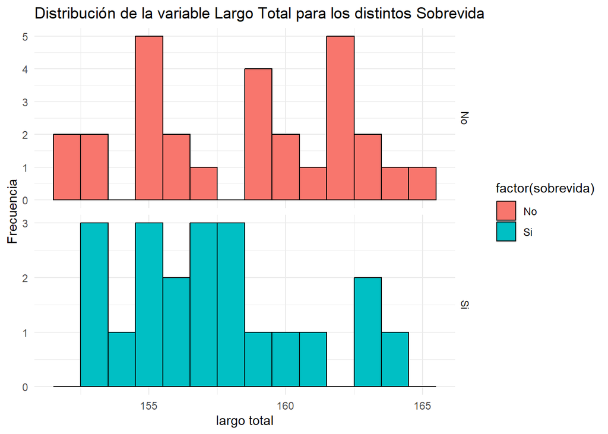

```r
#colnames(gorriones)[c(2,3,4,5,6)]
ggplot(gorriones, aes(x=largototal)) +
 geom_histogram(binwidth = 1, aes(x = largototal, fill = factor(sobrevida)), color = 'black') +
  facet_grid(sobrevida~., scales = 'free') +
  xlab("largo total") +
  ylab("Frecuencia") +
  ggtitle("Distribución de la variable Largo Total para los distintos Sobrevida") +
  theme_minimal()
```

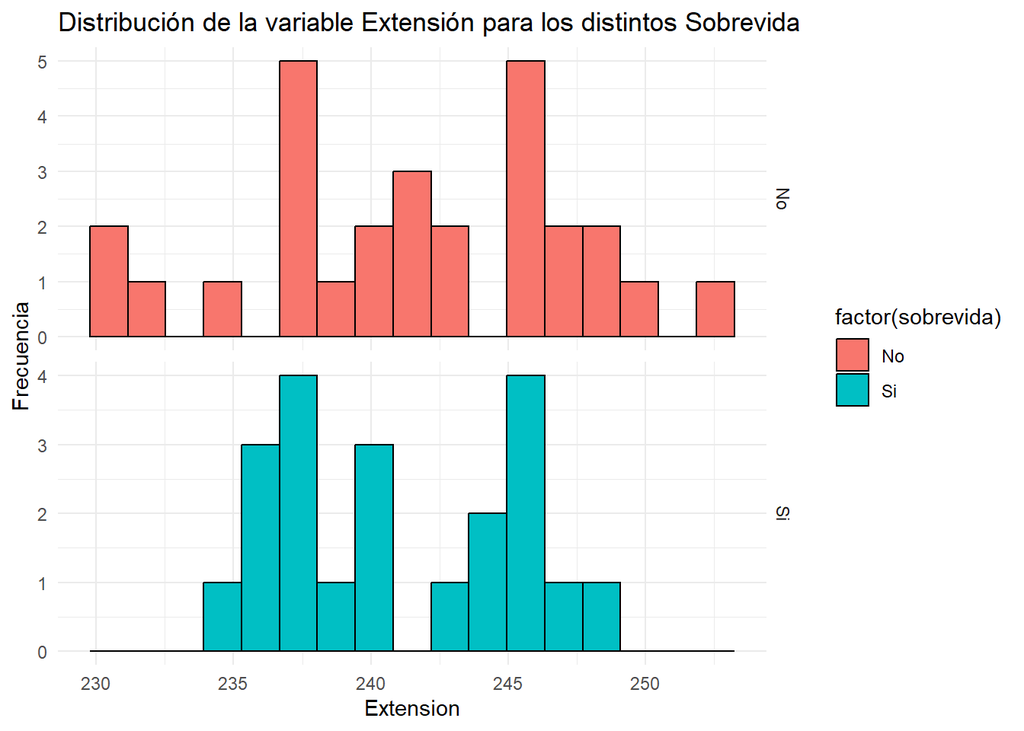

```r
ggplot(gorriones, aes(x=extension)) +
 geom_histogram(binwidth = 1.38, aes(x = extension, fill = factor(sobrevida)), color = 'black') +
  facet_grid(sobrevida~., scales = 'free') +
  xlab("Extension") +
  ylab("Frecuencia") +
  ggtitle("Distribución de la variable Extensión para los distintos Sobrevida") +
  theme_minimal()
```

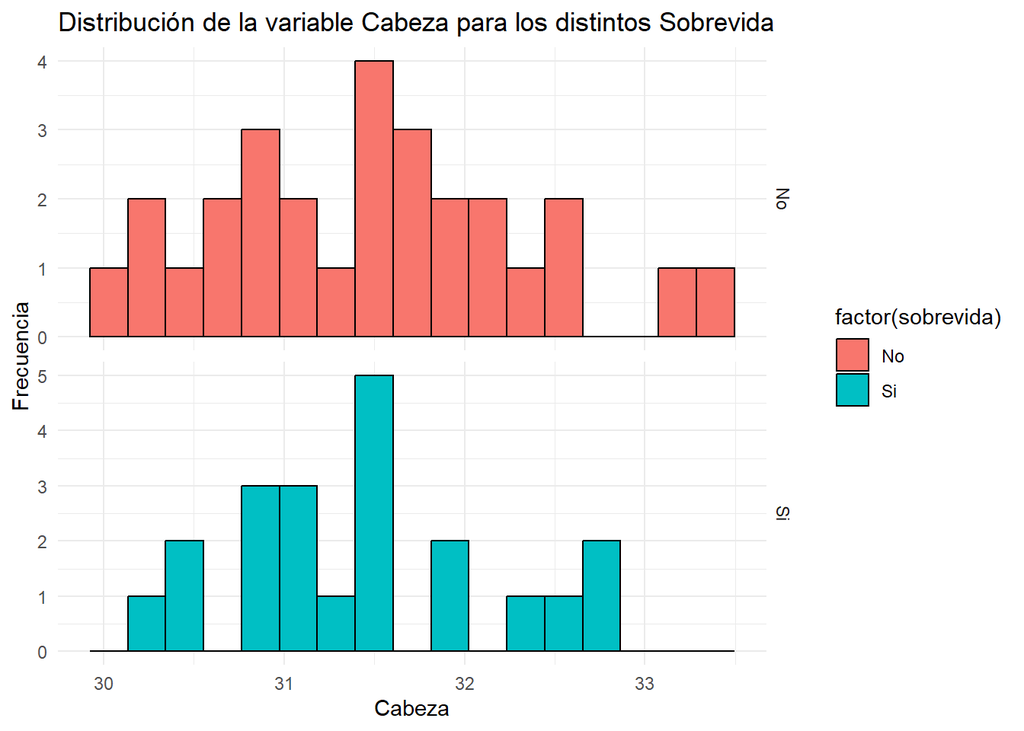

```r
ggplot(gorriones, aes(x=cabeza)) +
 geom_histogram(binwidth = 0.21, aes(x = cabeza, fill = factor(sobrevida)), color = 'black') +
  facet_grid(sobrevida~., scales = 'free') +
  xlab("Cabeza") +
  ylab("Frecuencia") +
  ggtitle("Distribución de la variable Cabeza para los distintos Sobrevida") +
  theme_minimal()
```

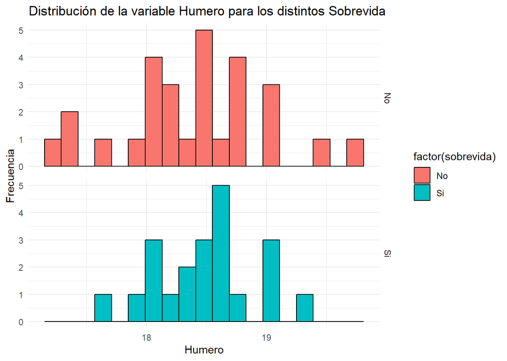

```r
ggplot(gorriones, aes(x=humero)) +
 geom_histogram(binwidth = 0.14, aes(x = humero, fill = factor(sobrevida)), color = 'black') +
  facet_grid(sobrevida~., scales = 'free') +
  xlab("Humero") +
  ylab("Frecuencia") +
  ggtitle("Distribución de la variable Humero para los distintos Sobrevida") +
  theme_minimal()
```